# Social mixing and clinical factors associated with XDR TB transmission in KwaZulu-Natal, South Africa

This repository includes source code for our analysis of factors associated with extensively drug-resistant (XDR) tuberculosis (TB) transmission in South Africa.

The models described are run in R using the EpiModel software.

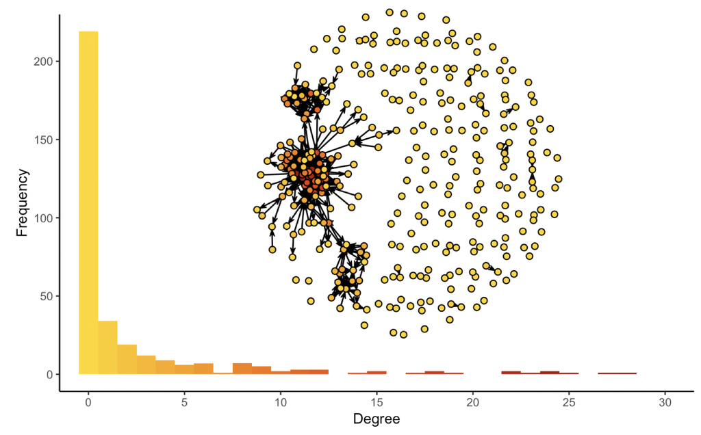

Network of XDR TB transmission in KwaZulu-Natal, South Africa

## Abstract

### Background

Tuberculosis (TB) is the leading infectious cause of death globally. and drug-resistant TB strains pose a serious threat to controlling the global TB epidemic. The clinical features, locations, and social factors driving transmission in settings with high incidence of drug-resistant TB are poorly understood.

### Methods

We measured a network of genomic links using Mycobacterium tuberculosis whole-genome sequences. Results. Patients with 2–3 months of cough or who spent time in urban locations were more likely to be linked in the network, while patients with sputum smear–positive disease were less likely to be linked than those with smear-negative disease. Associations persisted using different thresholds to define genomic links and irrespective of assumptions about the direction of transmission.

### Conclusions

Identifying factors that lead to many transmissions, including contact with urban areas, can suggest settings instrumental in transmission and indicate optimal locations and groups to target with interventions.

## Citation

Forthcoming!